# Math 120 Week 06

Prof Miller

26 March, 2021

# Mon March 22

## The most important distro: Normal!

Idea: you know what a prob dist is.

Now: Let’s learn the most important one: the normal dist (bell curve!)

Normal Dist: most of us are in the middle. It’s rare to be large or small!

“The” normal dist is actually a family of distributions. ALl have same shape,

- different center (mean)
- different spread (std dev)

Q: Given teh center and spread of a normal dist, how do we compute probabilities?

### Ex:

Adult men in the US have mean height 69“, stdev 2.7”. What’s the probability that a ranom man is less than 71" tall?

Ex: What’s the prob that rando man is between 68 an 70" tall?

Idea: PROBABILITY = AREA

PROBLEM: Can’t do it by hand!

Solution: Two ways:

1. Statistical Tables.
2. Software, like Google Sheets!

Problem: lots of different normal dists! But, only one table!

Answer: Always use the same one, the STANDARD NORMAL DISTRIBUTION:

- mean = 0
- std dev = 1

Problem: What if our data is normal, but not STANDARD normal? Ex: height!

ANSWER: Z-SCORES! Z-scores count how many std devs above/below the mean an observation is

```
Z = (X-mean)/stdev
```

### Ex:

If Z follows a std normal dist, find….

1. P(Z<1.23) = .8907
2. P(Z>1.23) = 1 - P(Z<1.23) = 1-.8907

```r
1-.8907
```

```
## [1] 0.1093
```

# Wed March 24

Last time: Z table shows area to the left of a z-score (std normal score).

### Ex:

If Z is std normal, find

1. P(Z< -1.85) = 0.0322
2. P(Z > -2.53) = 1 - P(Z < -2.53) = 1 - .0057

```r
1 - .0057
```

```
## [1] 0.9943
```

3. P( 0.64 < Z < 3.12) = P(Z<3.12) - P(<0.64) = .9991 - .7389

```r
.9991 - .7389
```

```
## [1] 0.2602
```

4. P( -2 < Z < 2) = P(Z<2) - P(Z<-2) = .9773 - .0228

```r
.9773 - .0228
```

```
## [1] 0.9545
```

Ah ha! That’s why the Emprical Rule works!

## Backwards Problems

So far: given Z, find area/prob. Forwards!

Now: given an area/prob, need to find Z. Backwards!

#### Ex:

What Z-score seperates the lower 80% of the normal dist from the upper 20%?

Ie, find the 80th percentile.

Find area = 0.8 in the table. Closest: area = 0.7995 -> Z = 0.84

#### Ex:

What z-score corresponds to the 99th percentile?

Find area = 0.99 in the table. Z = 2.33

## Practical Problems: Forwards

Idea: convert to z-score, look it up!

z = (x-mean)/stdev

#### Ex)

Height for women in the US follows normal dist with mean 64“, stdev 2.4”. Find the probability that random woman is….

1. P(X<70) = P(Z < (70-64)/2.4)

```r
(70-64)/2.4
```

```
## [1] 2.5
```

```
       = P(Z<2.5) = .9938
```

Ie, 99.38% of women are less than 5’10".

2. P( 60 < X < 65) = P( (60-64)/2.4 < Z < (65-64)/2.4 )

```r
(65 -64)/2.4
```

```
## [1] 0.4166667
```

```r
(60-64)/2.4
```

```
## [1] -1.666667
```

```
              = P( -1.67 < Z < 0.42 ) = .6628 - .0475
```

```r
.6628 - .0475
```

```
## [1] 0.6153
```

Ie, 61.53% of adult women are between 5’0" and 5’5".

3. P(X>75)

```r
(75 - 64)/2.4
```

```
## [1] 4.583333
```

```
 = P(Z>4.58) ~~ 0
```

Moral of the story: even if Z is “off the charts”, don’t let that stop you!

4. P(X<75) ~~ 1

## Practical Backwards Problems

Idea: look up z-score, solve for x.

```
z = (x-mean)/stdev

x = z*stdev + mean
```

#### Ex:

IQ follows a normal dist with mean 100, stdev 15.

1. How high must one’s IQ be in order to be in the top 10%?

Ie, 90th percentile. Look up area = 0.9000 in the table.

Z = 1.28

```
z = (x - mean)/stdev

1.28 = (x - 100)/15

x = 1.28*15 + 100
```

```r
1.28*15 + 100
```

```
## [1] 119.2
```

You’d need an IQ of at least 119.2 to be in the top 10%.

2. What IQ marks the 25th percentile?

In table, find area = 0.25

z = -.67

```
-.67 = (x - 100)/15
```

```r
(-.67)*15+100
```

```
## [1] 89.95
```

An IQ of 90 is at the 25th percentile.

# Friday March 26

## “Middle Percent” Problems

### Ex)

Height for men is normal with mean 69" stdev 2.7".

Q: What’s the range of the middle 50% of heights for men?

Note: backwards! Given area, need ranges of heights.

Need to look up area. But, what area?

For lo cutoff, look up area = 0.25, z = -0.67

For hi cutoff, look up area = 0.75, z = +0.67

Find heights:

lo: z = (x-mean)/stdev -0.67 = (x-69)/2.7

```r
-.67*2.7+69
```

```
## [1] 67.191
```

hi:

```r
.67*2.7+69
```

```
## [1] 70.809
```

Cutoffs for middle 50%: from 67.2" to 70.8".

Range:

```r
70.8-67.2
```

```
## [1] 3.6
```

Note: This is IQR! Range of middle 50%!

### Ex)

Mean IQ is 100, stdev 15, normal. Find range of middle 90% of IQ.

Find area = .05, both z=1.64 and 1.65 are equally good, split the diff:

```
 z = +/- 1.645
```

Cutoffs:

```
  x  = z*stdev+mean
```

```r
-1.645*15 + 100
```

```
## [1] 75.325
```

```r
1.645*15 + 100
```

```
## [1] 124.675
```

Range between 75.3 and 124.7:

```r
124.7-75.3
```

```
## [1] 49.4
```

CUTOFF FOR QUIZ. Quiz: normal dist! forwards and backwards! basic and practical! need z-table

## Sampling Distributions

So far: asking questions about individuals.

A “sampling dist” is a probability distribution for the likelihood of a SAMPLE STATISTIC.

- How likely is our sample mean? xbar
- How likely is our sample propotion? phat
- How likely is our sample stdev? s_x
- How likely is our cor coef? r

Ie: NOT ABOUT INDIVIDUALS! Instead, describing ENTIRE SAMPLES!

### Ex)

Suppose we roll two dice. Find the sampling dist for their mean, **xbar**.

Need two things:

- All possible values of xbar (all possible means of two dice)
- Find their probabilities

  xbar = 1 – (1,1)

  xbar = 1.5 – (1,2), (2,1)

  xbar = 2 – (1,3), (3,1), (2,2)

  xbar = 2.5 – (1,4), (4,1), (2,3), (3,2)

  xbar = 3 – (1,5), (5,1), (2,4), (4,2), (3,3)

  xbar = 3.5 – (1,6), (6,1), (2,5), (5,2) ,(3,4), (4,3)

  xbar = 4 – (2,6), (6,2), (3,5), (5,3), (4,4)

  ..

  xbar = 6 – (6,6)

Picture!

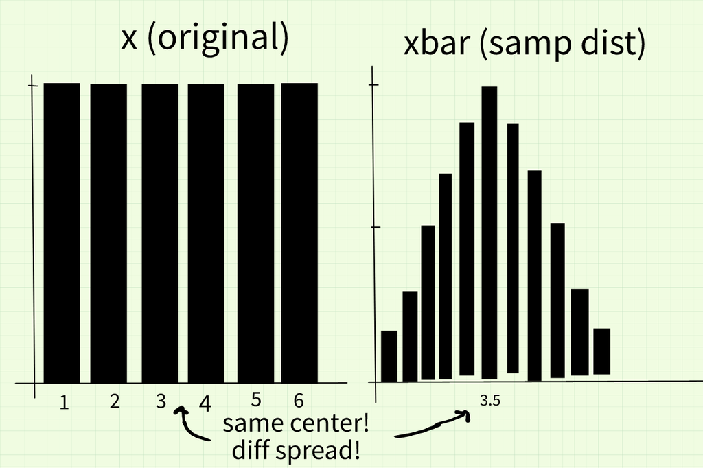

Observations:

1. Shape has changed! X has a “flat” distribution, Xbar has a peak in the middle
2. Spread has changed! X has larger spread than xbar!
3. Center has not changed!

These are always true for ALL sampling dists, no matter what x is, no matter what n (sample size):

- shape becomes more peaked in the middle (sound familiar?)
- spread smaller as n bigger
- center never changes!